# Allocate reported catch to VMS fishing pings

The catch is already Gulf of California landings. CONAPESCA records were kept when the landing site fell in an OHI region, and every site in Sonora, Sinaloa, and Nayarit was kept. The summary used here adds those landings by business, year, and taxonomic group for 2018–2024. It has no coordinates of its own.

VMS stores where that business’s vessels were. This notebook puts the year’s Gulf landings onto the pings that are slow enough to count as fishing, in proportion to the hours in each ping. The home state on the permit is not used. A vessel with a blank state still receives its business’s catch.

Slow pings on the Pacific side of Baja are removed before those hours are summed. The saved tracks reach 115°W, so they include the Pacific coast of the peninsula, and a longitude cut would also remove the northern Gulf. North of 22.75°N the divider is the western edge of the Gulf marine cells, which there is the Gulf coast of Baja. A ping west of that coast, and outside the marine cells, is left out of the weighting. From 22.75°N south to the bottom of the download, the divider is the meridian at 110.0°W. West of that line is the open Pacific southwest of Cabo and is removed the same way. East of it, the mouth and the approaches toward Sinaloa and Nayarit stay in the hours.

A ping is one vessel at one time. `hours` is the time since that vessel’s previous ping. Gaps longer than 3 hours are capped at 3 hours, so a long silence does not become a long stretch of fishing. A ping counts as fishing when `implied_speed_knots` is at most 6. That speed is the distance from the previous ping divided by the time gap. Faster pings are treated as transit and receive none of the catch.

For one economic unit in one year, the fishing hours are the sum of those capped hours across every vessel in the unit. Each fishing ping then receives

`catch on the ping = (capped hours on the ping / fishing hours of the unit) × catch of the unit`.

The shares for a unit add to 1, so the catch placed on its remaining pings adds back to the catch recorded for that unit. Catch from a unit with no vessel in the VMS registry, no slow ping in these files, or only Pacific pings, stays in the comparison table and off the map.

The catch file is split by taxonomic group. Those groups are added together before the split, so every species from a unit is placed with the same hour shares. A business that runs two gears therefore has both catches painted along both vessels’ slow tracks.

Gear and target travel with the vessel permit, joined on `vessel_rnpa`. That is the same join used for ghost-gear risk. Discard rates are a different Gilman table, with a finer split of trawl gears, so this notebook stops before converting catch into discards.

```r
library(terra)
library(tidyverse)
library(knitr)
```

```r
knitr::opts_chunk$set(fig.width = 8, fig.height = 6, message = FALSE, warning = FALSE)

vms_root <- "/home/shares/ohi/OHI_GOC/_raw_data/vms_juan_carlos"
# Identifiers are kept as text. Reading them as numbers drops a leading zero
# and the economic-unit join fails.
vessel_path <- file.path(vms_root, "vessel.csv")
catch_path <- file.path(
  "/home/frazier/ohi_goc_prep/FP/v2026/FP_Scores_1.0/FIS_Scores_1.0",
  "FIS_CPUE_SubScores/CPUE_In_Progress",
  "CatchPerEconomicUnit_group_summary_Jun102026.csv"
)

# Same 1 km marine grid used for the other vessel-effort rasters.
marine_path <- "/home/frazier/ohi_goc_prep/spatial/ohi_regions/ohi_marine_raster_1km.tif"
out_dir <- "/home/shares/ohi/OHI_GOC/goal_prep/pressures/vessels/catch_allocation"
fig_dir <- "/home/frazier/ohi_goc_prep/_pressures/vessels/figures"
dir.create(out_dir, showWarnings = FALSE, recursive = TRUE)
dir.create(fig_dir, showWarnings = FALSE, recursive = TRUE)

# Rules shared with the bottom-trawl and ghost-gear filters.
hours_cap <- 3
fishing_speed_knots <- 6

ohi_marine <- rast(marine_path)
ohi_marine <- ifel(ohi_marine >= 1, 1, NA)

# Western edge of the Gulf marine cells, in 0.25° latitude bands.
# From 22.75°N north this edge follows the Gulf coast of Baja.
peninsula_lat_min <- 22.75
pacific_buffer_deg <- 0.05
# South of the peninsula, the Pacific cut is this meridian.
pacific_meridian_lon <- -110
marine_xy <- as.data.frame(rast(marine_path), xy = TRUE, na.rm = TRUE)
marine_ll <- crds(project(vect(marine_xy, geom = c("x", "y"), crs = crs(ohi_marine)), "EPSG:4326"))
pacific_edge <- tibble(lon = marine_ll[, 1], lat = marine_ll[, 2]) %>%
  mutate(lat_band = floor(lat * 4) / 4) %>%
  filter(lat_band >= peninsula_lat_min) %>%
  group_by(lat_band) %>%
  summarise(west_lon = min(lon), .groups = "drop")
```

## 1. Vessel permits

Each row of the registry is one vessel. `eu_rnpa` is the business that owns it. `gear_type` and `target_species` are the gear and target on the permit. Home state is ignored, including rows where that field is blank. A vessel identifier occurs once, so the join does not duplicate pings.

```r
vessels <- read_csv(
  vessel_path,
  col_types = cols(
    vessel_rnpa = col_character(),
    eu_rnpa = col_character(),
    gear_type = col_character(),
    target_species = col_character(),
    .default = col_guess()
  )
) %>%
  filter(!is.na(eu_rnpa), eu_rnpa != "") %>%
  select(vessel_rnpa, eu_rnpa, gear_type, target_species)

# One row per vessel. A repeated identifier would copy pings and double-count catch.
stopifnot(anyDuplicated(vessels$vessel_rnpa) == 0)

cat(
  "Vessels:", nrow(vessels), "\n",
  "Economic units:", n_distinct(vessels$eu_rnpa), "\n"
)
```

```
## Vessels: 66074
##  Economic units: 8717
```

## 2. Reported catch

Catch is kilograms landed by an economic unit, a year, and a taxonomic group, from landing sites already kept as Gulf sites. The groups are summed so each unit has one catch for the year. The tonnes in this table are the Gulf landings the map has to account for.

```r
catch_groups <- read_csv(
  catch_path,
  col_types = cols(
    year = col_integer(),
    eu_rnpa = col_character(),
    Major_Functional_Group = col_character(),
    total_catch_kg = col_double()
  )
)

catch_by_unit <- catch_groups %>%
  group_by(year, eu_rnpa) %>%
  summarise(eu_catch_tonnes = sum(total_catch_kg, na.rm = TRUE) / 1000, .groups = "drop")

# Every tonne in the catch file, whether or not the unit has a VMS vessel.
catch_records <- catch_by_unit %>%
  group_by(year) %>%
  summarise(record_tonnes = sum(eu_catch_tonnes), .groups = "drop")

years <- sort(unique(catch_by_unit$year))

kable(
  catch_records,
  digits = 0,
  col.names = c("Year", "Reported catch, tonnes"),
  caption = "Gulf landings in the catch file, all economic units, before any VMS match."
)
```

Gulf landings in the catch file, all economic units, before any VMS match.

| Year | Reported catch, tonnes |
| --- | --- |
| 2018 | 902714 |
| 2019 | 897327 |
| 2020 | 877269 |
| 2021 | 1170338 |
| 2022 | 1026218 |
| 2023 | 1117301 |
| 2024 | 995773 |

## 3. Place each year’s catch on its fishing pings

The VMS files are large, so one year is read, allocated, written, and released before the next year starts. Within a year the steps are:

1. Join each ping to the vessel permit. Home state is not a filter.
2. Keep pings with a position, a positive time gap, and implied speed at or below 6 knots.
3. Cap the time gap at 3 hours.
4. Remove slow pings on the Pacific side of Baja. North of 22.75°N those pings are west of the Gulf coast of the peninsula. South of 22.75°N they are west of 110.0°W. Either way they are outside the marine cells. This happens before the hours are summed, so a Pacific trip does not take a share of the landings.
5. Sum the remaining hours for the economic unit.
6. Give each remaining ping its share of the unit’s catch.

A unit that landed fish and has no slow ping left after that filter contributes nothing to the map. Its tonnes remain in the record total. A unit with both Pacific and Gulf pings keeps its full landings, placed only on the Gulf-side pings.

```r
ping_path <- file.path(out_dir, "catch_tonnes_by_ping.csv")
if (file.exists(ping_path)) file.remove(ping_path)
```

```
## [1] TRUE
```

```r
# Sum of yearly catch rasters. Built up one year at a time.
catch_raster <- NULL
year_check <- vector("list", length(years))
# 0.1° bins of every saved ping, for the location map.
ping_map <- vector("list", length(years))
marine_values <- values(ohi_marine)[, 1]

for (i in seq_along(years)) {
  yr <- years[[i]]
  vms_path <- file.path(vms_root, "vms", sprintf("vms_%s.csv", yr))
  stopifnot(file.exists(vms_path))

  # Text identifiers again, so vessel_rnpa keeps its leading zeros.
  pings <- read_csv(
    vms_path,
    col_select = c(vessel_rnpa, datetime, lat, lon, year, hours, implied_speed_knots),
    col_types = cols(
      vessel_rnpa = col_character(),
      datetime = col_character(),
      lat = col_double(),
      lon = col_double(),
      year = col_integer(),
      hours = col_double(),
      implied_speed_knots = col_double()
    )
  ) %>%
    filter(!is.na(lat), !is.na(lon))

  # North of 22.75°N, west of the Gulf coast of Baja. A small buffer keeps a
  # ping just outside a marine cell on the Gulf side. South of 22.75°N, west
  # of 110.0°W. A ping already inside a marine cell is kept.
  ping_pts <- vect(pings, geom = c("lon", "lat"), crs = "EPSG:4326")
  ping_pts <- project(ping_pts, crs(ohi_marine))
  ping_cell <- cellFromXY(ohi_marine, crds(ping_pts))
  in_marine <- !is.na(ping_cell) & !is.na(marine_values[ping_cell])
  west_lon <- approx(
    pacific_edge$lat_band,
    pacific_edge$west_lon,
    xout = pings$lat,
    rule = 2
  )$y
  pings$pacific <- !in_marine & (
    (pings$lat >= peninsula_lat_min & pings$lon < (west_lon - pacific_buffer_deg)) |
      (pings$lat < peninsula_lat_min & pings$lon < pacific_meridian_lon)
  )

  ping_map[[i]] <- pings %>%
    mutate(
      lat_r = round(lat, 1),
      lon_r = round(lon, 1),
      side = if_else(pacific, "Pacific side of Baja", "Other VMS pings")
    ) %>%
    count(lat_r, lon_r, side, name = "n")

  pings <- pings %>%
    inner_join(vessels, by = "vessel_rnpa") %>%
    filter(
      !is.na(hours), hours > 0,
      !is.na(implied_speed_knots),
      implied_speed_knots <= fishing_speed_knots
    ) %>%
    mutate(hours_capped = pmin(hours, hours_cap))

  # Businesses whose only slow pings are on the Pacific side drop out.
  # Their landings are not given to any other business.
  kept_units <- pings %>%
    group_by(eu_rnpa) %>%
    summarise(any_kept = any(!pacific), .groups = "drop")
  pacific_only_tonnes <- catch_by_unit %>%
    filter(year == yr, eu_rnpa %in% kept_units$eu_rnpa[!kept_units$any_kept]) %>%
    summarise(tonnes = sum(eu_catch_tonnes)) %>%
    pull(tonnes)
  if (length(pacific_only_tonnes) == 0) pacific_only_tonnes <- 0
  n_pacific_pings <- sum(pings$pacific)

  pings <- pings %>%
    filter(!pacific)

  unit_hours <- pings %>%
    group_by(year, eu_rnpa) %>%
    summarise(eu_fishing_hours = sum(hours_capped), .groups = "drop")

  allocated <- pings %>%
    inner_join(unit_hours, by = c("year", "eu_rnpa")) %>%
    inner_join(filter(catch_by_unit, year == yr), by = c("year", "eu_rnpa")) %>%
    mutate(
      effort_ratio = hours_capped / eu_fishing_hours,
      catch_tonnes = effort_ratio * eu_catch_tonnes
    ) %>%
    select(
      year, vessel_rnpa, eu_rnpa, datetime, lat, lon,
      gear_type, target_species, implied_speed_knots,
      hours, hours_capped, eu_fishing_hours, eu_catch_tonnes,
      effort_ratio, catch_tonnes
    )

  # The shares for each unit should add to 1, and the tonnes should add
  # back to that unit's recorded catch.
  closure <- allocated %>%
    group_by(eu_rnpa) %>%
    summarise(
      ratio_sum = sum(effort_ratio),
      tonnes_sum = sum(catch_tonnes),
      eu_catch_tonnes = first(eu_catch_tonnes),
      .groups = "drop"
    )
  stopifnot(nrow(closure) == 0 || max(abs(closure$ratio_sum - 1)) < 1e-6)
  stopifnot(nrow(closure) == 0 || max(abs(closure$tonnes_sum - closure$eu_catch_tonnes)) < 1e-4)

  # The first year writes the header. Later years append rows only.
  write_csv(
    allocated,
    ping_path,
    append = i > 1,
    col_names = i == 1
  )

  # Drop the ping locations onto the marine grid. Cells outside the Gulf
  # mask stay empty. Background zero marks water with no catch this year.
  pts <- vect(allocated, geom = c("lon", "lat"), crs = "EPSG:4326")
  pts <- project(pts, crs(ohi_marine))
  year_raster <- rasterize(
    pts,
    y = ohi_marine,
    field = "catch_tonnes",
    fun = "sum",
    background = 0
  )
  year_raster <- ifel(is.na(ohi_marine), NA, year_raster)

  catch_raster <- if (is.null(catch_raster)) year_raster else catch_raster + year_raster

  matched_units <- catch_by_unit %>%
    filter(year == yr, eu_rnpa %in% vessels$eu_rnpa)

  year_check[[i]] <- tibble(
    year = yr,
    record_tonnes = catch_records$record_tonnes[catch_records$year == yr],
    vms_registry_tonnes = sum(matched_units$eu_catch_tonnes),
    pacific_only_tonnes = pacific_only_tonnes,
    allocated_tonnes = sum(allocated$catch_tonnes),
    raster_tonnes = as.numeric(global(year_raster, "sum", na.rm = TRUE)[1, 1]),
    n_pings = nrow(allocated),
    n_pacific_pings = n_pacific_pings
  )

  message(
    yr, ": ", nrow(allocated), " fishing pings, ",
    round(sum(allocated$catch_tonnes)), " tonnes allocated, ",
    n_pacific_pings, " Pacific pings removed"
  )
  rm(pings, allocated, pts, year_raster, closure, ping_pts)
  gc(verbose = FALSE)
}

year_check <- list_rbind(year_check)
names(catch_raster) <- "catch_tonnes"
```

## 4. Where the VMS pings are

Every saved ping with a position is counted in 0.1° cells. Red cells are west of the black line and are removed before the weighting. North of 22.75°N that line is the Gulf coast of Baja. From there south it is the meridian at 110.0°W. Blue cells stay in the weighting, including the mouth and the approaches toward Sinaloa and Nayarit.

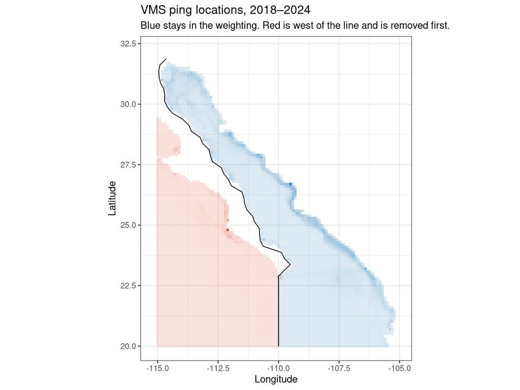

```r
ping_map_all <- list_rbind(ping_map) %>%
  group_by(lat_r, lon_r, side) %>%
  summarise(n = sum(n), .groups = "drop")

coast <- pacific_edge %>%
  transmute(lon = west_lon - pacific_buffer_deg, lat = lat_band + 0.125) %>%
  arrange(lat)
divider <- bind_rows(
  tibble(lon = pacific_meridian_lon, lat = c(20, peninsula_lat_min)),
  coast
)

ping_plot <- ggplot() +
  geom_tile(
    data = filter(ping_map_all, side == "Other VMS pings"),
    aes(lon_r, lat_r, alpha = n),
    fill = "#2c7fb8"
  ) +
  geom_tile(
    data = filter(ping_map_all, side == "Pacific side of Baja"),
    aes(lon_r, lat_r, alpha = n),
    fill = "#e34a33"
  ) +
  geom_path(data = divider, aes(lon, lat), linewidth = 0.4) +
  scale_alpha_continuous(range = c(0.15, 1), trans = "sqrt", guide = "none") +
  coord_fixed(xlim = c(-115.2, -105), ylim = c(20, 32.2)) +
  labs(
    title = "VMS ping locations, 2018–2024",
    subtitle = "Blue stays in the weighting. Red is west of the line and is removed first.",
    x = "Longitude",
    y = "Latitude"
  ) +
  theme_bw()

print(ping_plot)
```

```r
ggsave(
  file.path(fig_dir, "vms_ping_locations_2018_2024.png"),
  ping_plot,
  width = 8,
  height = 8,
  dpi = 150,
  bg = "white"
)
```

## 5. Compare the map with the catch records

The record total is every tonne of Gulf landings in the catch file. The VMS registry total is the part whose business has a vessel in the registry, whatever the home state says. The Pacific-only total is the part whose slow pings were all on the Pacific side of Baja, so nothing remained to weight. The allocated total is the part placed on the remaining slow pings. The raster total is the allocated catch that lands inside the Gulf marine grid. Pings east of 110.0°W and south of 22.75°N stay in the weighting and can still fall outside that grid.

```r
kable(
  year_check %>%
    mutate(off_raster_tonnes = allocated_tonnes - raster_tonnes),
  digits = 0,
  col.names = c(
    "Year",
    "Gulf landings, t",
    "Businesses with a VMS vessel, t",
    "Only Pacific pings, t",
    "Placed on remaining slow pings, t",
    "Inside the marine grid, t",
    "Fishing pings kept",
    "Pacific pings removed",
    "Pings outside the grid, t"
  ),
  caption = "Each row is one year. Placed tonnes equal the recorded catch of units that still had a slow ping after the Pacific pings were removed."
)
```

Each row is one year. Placed tonnes equal the recorded catch of units that still had a slow ping after the Pacific pings were removed.

| Year | Gulf landings, t | Businesses with a VMS vessel, t | Only Pacific pings, t | Placed on remaining slow pings, t | Inside the marine grid, t | Fishing pings kept | Pacific pings removed | Pings outside the grid, t |
| --- | --- | --- | --- | --- | --- | --- | --- | --- |
| 2018 | 902714 | 897419 | 82 | 701261 | 684494 | 1659954 | 204696 | 16767 |
| 2019 | 897327 | 893929 | 84 | 711776 | 693507 | 1561927 | 229591 | 18269 |
| 2020 | 877269 | 876060 | 228 | 746809 | 721295 | 1108516 | 155318 | 25514 |
| 2021 | 1170338 | 1166358 | 185 | 951276 | 930669 | 1173822 | 177464 | 20607 |
| 2022 | 1026218 | 1021335 | 159 | 813167 | 785989 | 587751 | 91092 | 27178 |
| 2023 | 1117301 | 1110637 | 56 | 951586 | 913638 | 698708 | 75732 | 37948 |
| 2024 | 995773 | 974574 | 0 | 773844 | 729057 | 778765 | 126326 | 44787 |

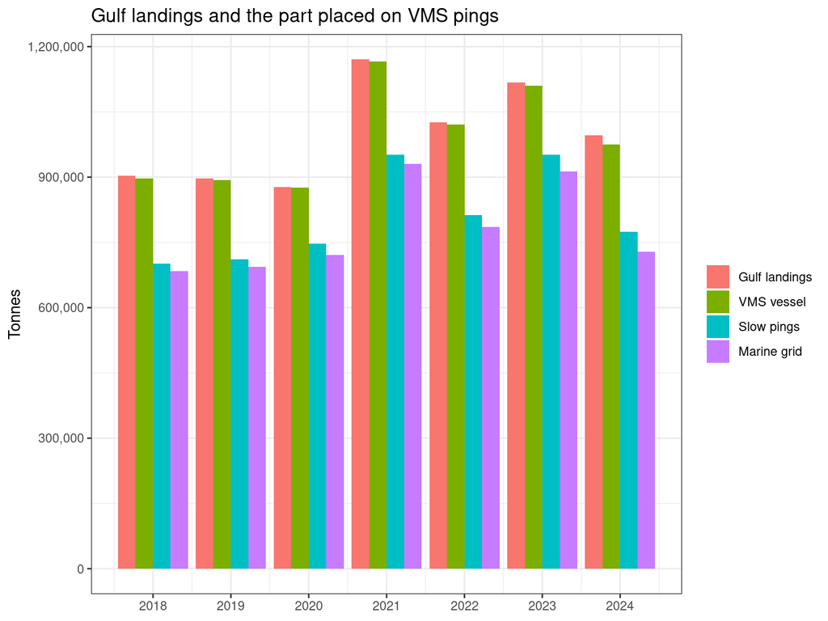

```r
compare_long <- year_check %>%
  select(year, record_tonnes, vms_registry_tonnes, allocated_tonnes, raster_tonnes) %>%
  pivot_longer(-year, names_to = "source", values_to = "tonnes") %>%
  mutate(
    source = recode(
      source,
      record_tonnes = "Gulf landings",
      vms_registry_tonnes = "VMS vessel",
      allocated_tonnes = "Slow pings",
      raster_tonnes = "Marine grid"
    ),
    source = factor(
      source,
      levels = c("Gulf landings", "VMS vessel", "Slow pings", "Marine grid")
    )
  )

compare_plot <- ggplot(compare_long, aes(year, tonnes, fill = source)) +
  geom_col(position = "dodge") +
  scale_x_continuous(breaks = years) +
  scale_y_continuous(labels = scales::label_comma()) +
  labs(
    title = "Gulf landings and the part placed on VMS pings",
    x = NULL,
    y = "Tonnes",
    fill = NULL
  ) +
  theme_bw()

print(compare_plot)
```

```r
ggsave(
  file.path(fig_dir, "catch_allocation_vs_records.png"),
  compare_plot,
  width = 8,
  height = 5,
  dpi = 150,
  bg = "white"
)
```

```r
comparison_path <- file.path(out_dir, "catch_allocation_vs_records.csv")
write_csv(year_check, comparison_path)
```

## 6. Where the catch was placed

The raster is the sum of 2018–2024. Empty water is left blank. The color scale is square-root, so a cell with a modest catch is still visible next to the sardine and shrimp grounds.

```r
raster_path <- file.path(out_dir, "catch_tonnes_2018_2024_1km.tif")
# Zeros are water with no allocated catch. Store them as empty cells.
catch_plot_raster <- ifel(catch_raster > 0, catch_raster, NA)
names(catch_plot_raster) <- "catch_tonnes"
writeRaster(catch_plot_raster, raster_path, overwrite = TRUE)
```

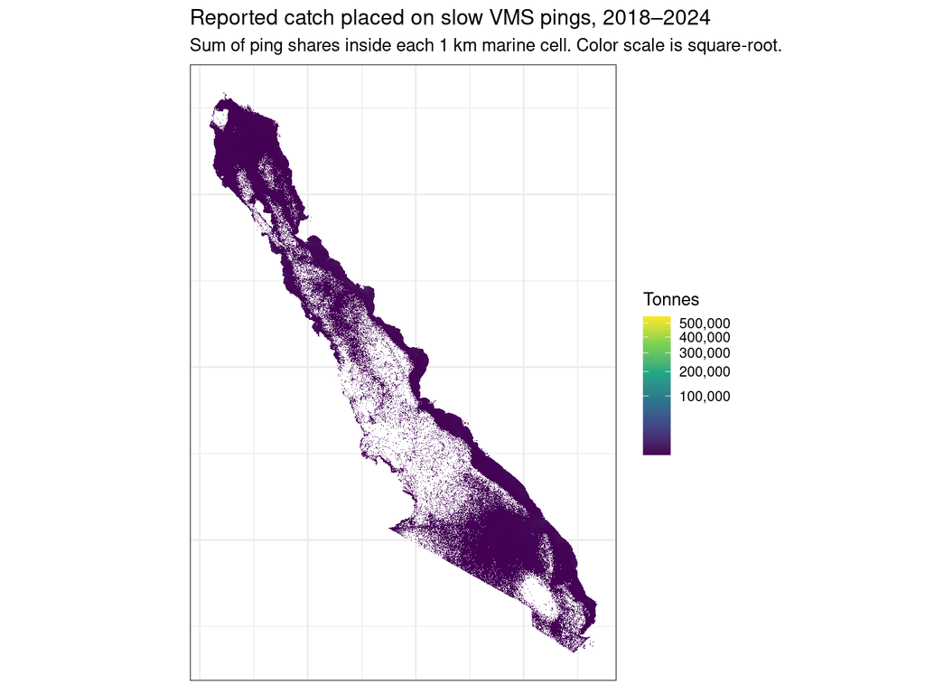

```r
plot_df <- as.data.frame(catch_plot_raster, xy = TRUE, na.rm = TRUE)
names(plot_df)[3] <- "catch_tonnes"

raster_plot <- ggplot(plot_df, aes(x, y, fill = catch_tonnes)) +
  geom_raster() +
  scale_fill_viridis_c(
    trans = "sqrt",
    name = "Tonnes",
    labels = scales::label_comma()
  ) +
  coord_equal() +
  labs(
    title = "Reported catch placed on slow VMS pings, 2018–2024",
    subtitle = "Sum of ping shares inside each 1 km marine cell. Color scale is square-root.",
    x = NULL,
    y = NULL
  ) +
  theme_bw() +
  theme(axis.text = element_blank(), axis.ticks = element_blank())

print(raster_plot)
```

```r
ggsave(
  file.path(fig_dir, "catch_tonnes_2018_2024_1km.png"),
  raster_plot,
  width = 8,
  height = 7,
  dpi = 150,
  bg = "white"
)
```

## 7. The ping table

/home/shares/ohi/OHI_GOC/goal_prep/pressures/vessels/catch_allocation/catch_tonnes_by_ping.csv has one row per slow ping that received catch. `catch_tonnes` is that ping’s share of its economic unit’s landings. `gear_type` and `target_species` are the permit fields, joined on `vessel_rnpa` in the same way as the ghost-gear layer.

The raster is /home/shares/ohi/OHI_GOC/goal_prep/pressures/vessels/catch_allocation/catch_tonnes_2018_2024_1km.tif. The year-by-year comparison is /home/shares/ohi/OHI_GOC/goal_prep/pressures/vessels/catch_allocation/catch_allocation_vs_records.csv.

## 8. Stopping before discards

The ghost-gear layer joins these same `gear_type` and `target_species` values to `gear_gilman_crosswalk.csv`. That crosswalk points at Gilman et al. 2021, the abandoned-gear risk scores. Shrimp trawl and other bottom trawls share the category “Trawl, bottom”.

Discard rates live in a different paper, Gilman et al. 2020, *Benchmarking global fisheries discards*. There, shrimp trawl discards about 55% of total catch and bottom trawl as a group discards about 22%. Those rates are discards per tonne of landings plus discards, and the reported catch here is landings. Using the 2021 category as if it were the 2020 rate would give shrimp and other trawls the same discards per tonne.

The ping table is ready for that next decision. Discard tonnes are not written here.